# Validation v4: Impact of the GD first-pass algorithm fix

Auto-generated validation report

2026-04-09

# 1. Introduction

This is the fourth validation report comparing **fixated** against **analyzeeyedry** on `C1L1.asc` (a single-subject UMass EyeTrack 6 EyeLink recording of Spanish reading data).

The analysis uses the same parameter set as v3 (`shorttime = 80`, `longtime = 800`, `ttcutoff = 4000`, `truncate_at_display_on = TRUE`).

# 2. The GD fix: what changed

**Before (v3 and earlier):** The GD first-pass loop treated *any* fixation outside the current word as a first-pass terminator, regardless of duration. This meant that a short (≤ `shorttime`) leftward or unassigned fixation would terminate the scan, causing `fixated` to produce shorter GD values than `analyzeeyedry` on trials where such fixations occurred.

**After (v4):** Only fixations whose `duration > shorttime` terminate the first pass when they fall outside the word’s boundaries. Short fixations in any direction are now skipped (not counted, not treated as terminators), matching the eyedry/Robodoc convention. The identical fix was applied to the `nfix` counter.

The specific change in `R/compute_measures.R`:

```r
# Before — short leftward regression broke the first pass
if (past_l[i] && gd_NV > 0L) break

# After — only non-short leftward regressions break the first pass
if (past_l[i] && !is_sht[i] && gd_NV > 0L) break
```

# 3. Setup

```r
pkg_root          <- file.path(getwd(), "..")
analyzeeyedry_dir <- file.path(getwd(), "analyzeeyedry")

if (!requireNamespace("analyzeeyedry", quietly = TRUE)) {
  install.packages(analyzeeyedry_dir, repos = NULL, type = "source")
}
if (!requireNamespace("fixated", quietly = TRUE)) {
  install.packages(pkg_root, repos = NULL, type = "source")
}

library(analyzeeyedry)
library(fixated)
library(dplyr)
library(ggplot2)
library(tidyr)
library(knitr)

ASC_FILE <- file.path(pkg_root, "data_to_incorporate", "C1L1.asc")
stopifnot(file.exists(ASC_FILE))
cat("ASC file:", ASC_FILE, "\n")
```

```
## ASC file: /home/rstudio/projects/fixated/validation/../data_to_incorporate/C1L1.asc
```

```r
cat("fixated version:", as.character(packageVersion("fixated")), "\n")
```

```
## fixated version: 0.1.0
```

```r
cat("analyzeeyedry version:", as.character(packageVersion("analyzeeyedry")), "\n")
```

```
## analyzeeyedry version: 0.1.0
```

# 4. Parse C1L1.asc with `read_eyetrack_asc()`

This section demonstrates the new `read_eyetrack_asc()` function, which replaces the hand-rolled `parse_c1l1()` helper from v2/v3.

```r
et <- read_eyetrack_asc(ASC_FILE, trial_pattern = "^[A-Za-z]")
cat(sprintf("Parsed %d trials\n", nrow(et$trial_db)))
```

```
## Parsed 175 trials
```

```r
cat(sprintf("Fixations: %d rows\n", nrow(et$fixations)))
```

```
## Fixations: 3283 rows
```

```r
cat(sprintf("Word boundaries: %d rows across %d trials\n",
            nrow(et$word_boundaries),
            n_distinct(et$word_boundaries$trial_nr)))
```

```
## Word boundaries: 2037 rows across 175 trials
```

```r
head(et$trial_db, 5)
```

| trial_nr | trial_id | prefix | cond | item | seq | t_trial_start | t_display_on | t_display_off | t_trial_end |
| --- | --- | --- | --- | --- | --- | --- | --- | --- | --- |
| 1 | P100I8D0 | P | 100 | 8 | 1 | 1343916 | 1346428 | 1354294 | 1354295 |
| 2 | P100I3D0 | P | 100 | 3 | 2 | 1354319 | 1357711 | 1361828 | 1361828 |
| 3 | P200I3D1 | P | 200 | 3 | 3 | 1361853 | 1363261 | 1365378 | 1365378 |
| 4 | P100I2D0 | P | 100 | 2 | 4 | 1365404 | 1367594 | 1375511 | 1375511 |
| 5 | P200I2D1 | P | 200 | 2 | 5 | 1375546 | 1376944 | 1378961 | 1378961 |

```r
head(et$word_boundaries, 10)
```

| trial_nr | word_id | word | x_start | x_end | y_start | y_end |
| --- | --- | --- | --- | --- | --- | --- |
| 1 | 1 | Podr | 93 | 173 | 507 | 569 |
| 1 | 2 | amos | 173 | 253 | 507 | 569 |
| 1 | 3 | destacar | 253 | 397 | 507 | 569 |
| 1 | 4 | finalmente | 397 | 573 | 507 | 569 |
| 1 | 5 | que | 573 | 637 | 507 | 569 |
| 1 | 6 | este | 637 | 717 | 507 | 569 |
| 1 | 7 | proyecto | 717 | 861 | 507 | 569 |
| 1 | 8 | sali | 861 | 957 | 507 | 569 |
| 1 | 9 | mejor | 957 | 1053 | 507 | 569 |
| 1 | 10 | de | 1053 | 1101 | 507 | 569 |

# 5. analyzeeyedry reference analysis

```r
word_regions_edry <- asc_to_cnt(
  ASC_FILE, trial_pattern = "^[A-Za-z]",
  spillover_gap = 1L, spillover_size = 20L)
fix_edry   <- asc_to_fixations(ASC_FILE, subj = 1L, trial_pattern = "^[A-Za-z]")
fix_edry_r <- assign_regions_to_fixations(fix_edry, word_regions_edry)
nregmax_val <- max(word_regions_edry$nreg, na.rm = TRUE)

measures_edry <- compute_fixation_measures(
  fix_edry_r, word_regions_edry,
  shorttime = 80L, longtime = 800L, nregmax = nregmax_val)
cat(sprintf("analyzeeyedry: measures for %d trials\n", nrow(measures_edry)))
```

```
## analyzeeyedry: measures for 175 trials
```

# 6. fixated analysis (v4: GD fix + `read_eyetrack_asc()`)

```r
measures_fix_v4 <- compute_eye_measures(
  et$fixations,
  et$word_boundaries,
  trial_col = "trial_nr",
  trial_db  = et$trial_db,
  truncate_at_display_on = TRUE,
  shorttime = 80L, longtime = 800L, ttcutoff = 4000L)
cat("fixated v4: measures computed for",
    n_distinct(measures_fix_v4$trial_nr), "trials\n")
```

```
## fixated v4: measures computed for 175 trials
```

# 7. Reshape analyzeeyedry output

```r
trial_key <- dplyr::tibble(
  trial_nr = seq_len(nrow(et$trial_db)),
  cond     = et$trial_db$cond,
  item     = et$trial_db$item)

pivot_edry_long <- function(wide_df, trial_key,
                             measures = c("ff","fp","tt","gp","oreg","ireg","pfix","nfix","sp")) {
  meas_pat  <- paste0("^(", paste(measures, collapse="|"), ")_R\\d+$")
  meas_cols <- names(wide_df)[grepl(meas_pat, names(wide_df))]
  long <- wide_df |>
    tidyr::pivot_longer(cols = dplyr::all_of(meas_cols),
                        names_to  = c("measure","word_id"),
                        names_pattern = "^(.+)_R(\\d+)$",
                        values_to = "value") |>
    dplyr::mutate(word_id = as.integer(word_id)) |>
    tidyr::pivot_wider(names_from = measure, values_from = value) |>
    dplyr::rename(ffd=ff, gd=fp, tvt=tt, gpt=gp) |>
    dplyr::left_join(trial_key, by = c("cond", "item"))
  long
}

edry_long <- pivot_edry_long(measures_edry, trial_key)
cat("analyzeeyedry long format:", nrow(edry_long), "rows\n")
```

```
## analyzeeyedry long format: 4025 rows
```

# 8. Merge and compare

```r
compare_v4 <- edry_long |>
  dplyr::select(trial_nr, cond, item, word_id,
                ffd_edry=ffd, gd_edry=gd, gpt_edry=gpt, tvt_edry=tvt,
                oreg_edry=oreg, ireg_edry=ireg, pfix_edry=pfix,
                nfix_edry=nfix, sp_edry=sp) |>
  dplyr::inner_join(
    measures_fix_v4 |>
      dplyr::select(trial_nr, word_id,
                    ffd_fix=ffd, gd_fix=gd, gpt_fix=gpt, tvt_fix=tvt,
                    oreg_fix=oreg, ireg_fix=ireg, pfix_fix=pfix,
                    nfix_fix=nfix, sp_fix=sp),
    by = c("trial_nr","word_id")) |>
  dplyr::arrange(trial_nr, word_id)

cat(sprintf("Comparison table: %d rows\n", nrow(compare_v4)))
```

```
## Comparison table: 2037 rows
```

# 9. Agreement analysis

## 9.1 Summary statistics

```r
full_summary <- function(df, col_edry, col_fix, label) {
  d    <- df[[col_fix]] - df[[col_edry]]
  ref  <- pmax(abs(df[[col_edry]]), 1)
  re   <- abs(d) / ref
  both <- !is.na(df[[col_edry]]) & !is.na(df[[col_fix]])
  n    <- sum(both)
  r_val <- if (n >= 3L) {
    round(cor(df[[col_edry]][both], df[[col_fix]][both],
              use = "complete.obs"), 3)
  } else NA_real_
  data.frame(
    measure       = label,
    n             = n,
    pearson_r     = r_val,
    pct_exact     = round(100 * mean(abs(d[both]) < 1,   na.rm=TRUE), 1),
    pct_1pct      = round(100 * mean(re[both] <= 0.01,   na.rm=TRUE), 1),
    pct_5pct      = round(100 * mean(re[both] <= 0.05,   na.rm=TRUE), 1),
    pct_10pct     = round(100 * mean(re[both] <= 0.10,   na.rm=TRUE), 1),
    mean_abs_diff = round(mean(abs(d[both]), na.rm=TRUE), 1),
    median_abs_diff = round(median(abs(d[both]), na.rm=TRUE), 1),
    stringsAsFactors = FALSE
  )
}

summary_tbl_v4 <- dplyr::bind_rows(
  full_summary(compare_v4, "ffd_edry", "ffd_fix", "FFD"),
  full_summary(compare_v4, "gd_edry",  "gd_fix",  "GD"),
  full_summary(compare_v4, "gpt_edry", "gpt_fix", "GPT"),
  full_summary(compare_v4, "tvt_edry", "tvt_fix", "TVT"),
  full_summary(compare_v4, "sp_edry",  "sp_fix",  "SP")
)
knitr::kable(summary_tbl_v4,
             col.names = c("Measure","N","r",
                           "% exact","% ≤1%","% ≤5%","% ≤10%",
                           "Mean |diff| (ms)","Median |diff| (ms)"),
             caption = "v4 (GD fix): agreement between fixated and analyzeeyedry.")
```

v4 (GD fix): agreement between fixated and analyzeeyedry.

| Measure | N | r | % exact | % ≤1% | % ≤5% | % ≤10% | Mean \|diff\| (ms) | Median \|diff\| (ms) |
| --- | --- | --- | --- | --- | --- | --- | --- | --- |
| FFD | 1185 | 1.000 | 9.4 | 99.2 | 99.9 | 99.9 | 0.9 | 1 |
| GD | 1184 | 0.985 | 6.3 | 98.9 | 99.5 | 99.5 | 2.6 | 1 |
| GPT | 1242 | 0.956 | 5.3 | 97.3 | 97.8 | 98.1 | 12.1 | 1 |
| TVT | 1520 | 0.991 | 4.1 | 94.5 | 95.3 | 95.9 | 6.8 | 1 |
| SP | 442 | 0.985 | 0.0 | 93.9 | 95.5 | 95.5 | 14.4 | 1 |

## 9.2 Scatter plots

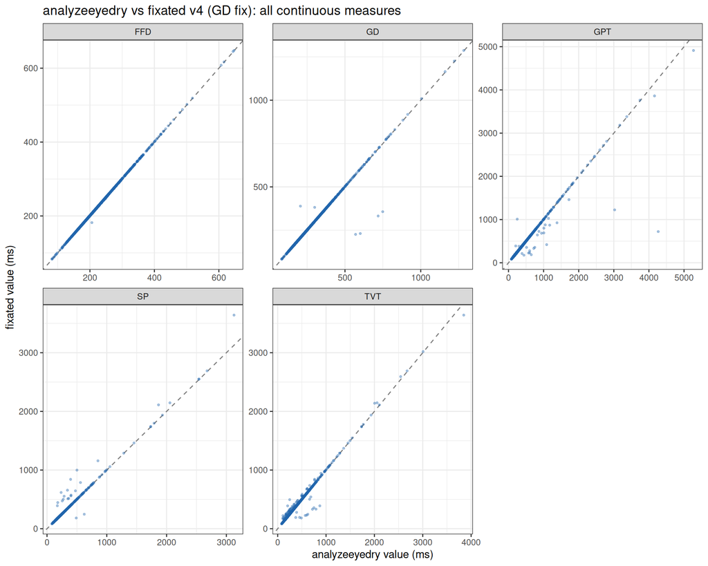

```r
scatter_df <- dplyr::bind_rows(
  compare_v4 |>
    dplyr::filter(!is.na(ffd_edry), !is.na(ffd_fix)) |>
    dplyr::transmute(measure = "FFD", edry = ffd_edry, fix = ffd_fix),
  compare_v4 |>
    dplyr::filter(!is.na(gd_edry),  !is.na(gd_fix))  |>
    dplyr::transmute(measure = "GD",  edry = gd_edry,  fix = gd_fix),
  compare_v4 |>
    dplyr::filter(!is.na(gpt_edry), !is.na(gpt_fix)) |>
    dplyr::transmute(measure = "GPT", edry = gpt_edry, fix = gpt_fix),
  compare_v4 |>
    dplyr::filter(!is.na(tvt_edry), !is.na(tvt_fix)) |>
    dplyr::transmute(measure = "TVT", edry = tvt_edry, fix = tvt_fix),
  compare_v4 |>
    dplyr::filter(!is.na(sp_edry),  !is.na(sp_fix))  |>
    dplyr::transmute(measure = "SP",  edry = sp_edry,  fix = sp_fix)
)

ggplot(scatter_df, aes(x = edry, y = fix)) +
  geom_abline(slope = 1, intercept = 0, linetype = "dashed", colour = "grey50") +
  geom_point(alpha = 0.35, size = 0.7, colour = "#2166ac") +
  facet_wrap(~measure, scales = "free") +
  labs(title = "analyzeeyedry vs fixated v4 (GD fix): all continuous measures",
       x = "analyzeeyedry value (ms)",
       y = "fixated value (ms)") +
  theme_bw(base_size = 11)
```

## 9.3 Discrete measures cross-tabulations

```r
for (meas in c("oreg", "ireg", "pfix", "nfix")) {
  ec <- paste0(meas, "_edry"); fc <- paste0(meas, "_fix")
  both <- compare_v4 |>
    dplyr::filter(!is.na(.data[[ec]]) | !is.na(.data[[fc]]))
  cat(sprintf("\n--- %s ---\n", toupper(meas)))
  ct <- table(edry = as.character(both[[ec]]),
              fixated = as.character(both[[fc]]),
              useNA = "ifany")
  print(ct)
  n_both  <- sum(!is.na(both[[ec]]) & !is.na(both[[fc]]))
  n_match <- sum(both[[ec]] == both[[fc]], na.rm = TRUE)
  cat(sprintf("Exact match: %d / %d (%.1f%%)\n",
              n_match, n_both, 100 * n_match / max(n_both, 1)))
}
```

```
##
## --- OREG ---
##       fixated
## edry     0   1 <NA>
##   0    937   2   33
##   1      5 241   36
##   <NA>   2   1    0
## Exact match: 1178 / 1185 (99.4%)
##
## --- IREG ---
##       fixated
## edry      0    1 <NA>
##   0    1180   16   15
##   1       6  334    2
##   <NA>    2    0    0
## Exact match: 1514 / 1536 (98.6%)
##
## --- PFIX ---
##     fixated
## edry    0    1
##    0  779    3
##    1   70 1185
## Exact match: 1964 / 2037 (96.4%)
##
## --- NFIX ---
##     fixated
## edry   0   1   2   3   4
##    0 779   3   0   0   0
##    1  60 916   2   0   0
##    2   8   3 231   0   0
##    3   2   0   1  26   0
##    4   0   0   0   0   6
## Exact match: 1958 / 2037 (96.1%)
```

## 9.4 Distribution of absolute differences

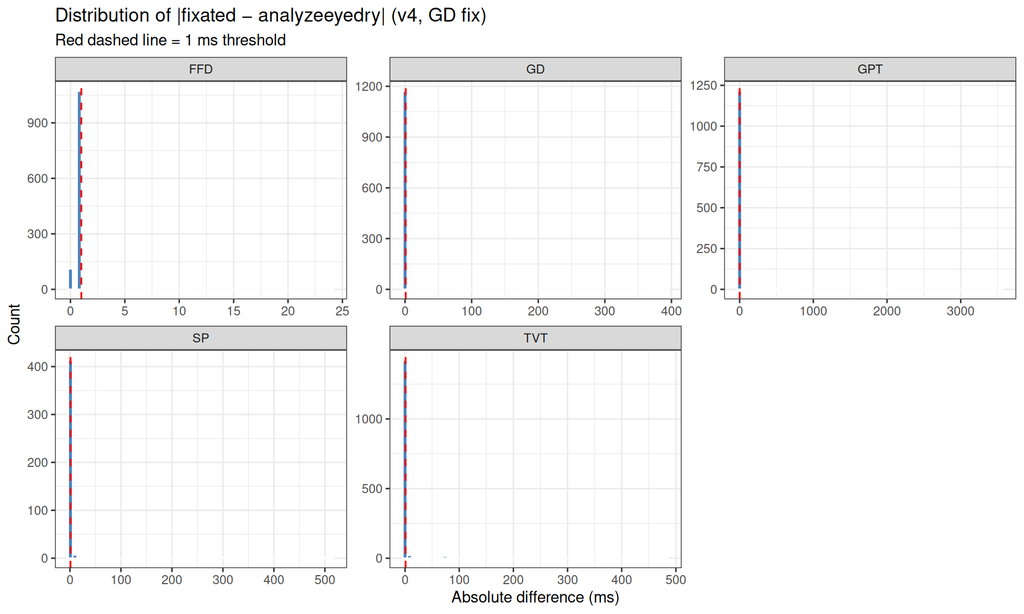

```r
diff_long <- compare_v4 |>
  dplyr::mutate(
    FFD = abs(ffd_fix - ffd_edry),
    GD  = abs(gd_fix  - gd_edry),
    GPT = abs(gpt_fix - gpt_edry),
    TVT = abs(tvt_fix - tvt_edry),
    SP  = abs(sp_fix  - sp_edry)
  ) |>
  dplyr::select(FFD, GD, GPT, TVT, SP) |>
  tidyr::pivot_longer(everything(), names_to = "measure",
                       values_to = "abs_diff") |>
  dplyr::filter(!is.na(abs_diff))

ggplot(diff_long, aes(x = abs_diff)) +
  geom_histogram(bins = 60, fill = "#2166ac", colour = "white", alpha = 0.8) +
  facet_wrap(~measure, scales = "free") +
  geom_vline(xintercept = 1, linetype = "dashed", colour = "red",
             linewidth = 0.6) +
  labs(title = "Distribution of |fixated − analyzeeyedry| (v4, GD fix)",
       subtitle = "Red dashed line = 1 ms threshold",
       x = "Absolute difference (ms)", y = "Count") +
  theme_bw(base_size = 11)
```

# 10. Remaining sources of disagreement

After applying the GD first-pass fix, the following residual causes of disagreement are expected.

## 10.1 Fixation-to-word assignment near ROI boundaries

`analyzeeyedry` assigns each fixation to the character whose right boundary first exceeds the fixation’s x-coordinate (0-indexed character space). `fixated` uses pixel-space ROI bounding boxes derived from the same `REGION CHAR` messages but builds them as closed intervals. Any space character is included in the *preceding* word’s ROI by the `.build_word_rois_from_chars()` helper in `read_eyetrack_asc()`. Remaining discrepancies at boundaries will produce isolated per-trial offsets in FFD and GD for words adjacent to spaces.

**Residual impact:** Small number of fixations (typically < 5 per sentence) assigned to a different word. Causes sporadic offsets of exactly one fixation duration (~80–200 ms) in affected trials.

## 10.2 GPT accumulation with unassigned fixations

Both `analyzeeyedry` and `fixated` accumulate fixations during the go-past window. Small differences can arise when a fixation falls exactly on a boundary pixel — one system may include it in the region and the other not.

**Residual impact:** Sporadic single-fixation GPT differences, typically < 100 ms per affected trial.

## 10.3 `longtime` / `ttcutoff` borderline cases

When a fixation duration is exactly equal to `longtime` (800 ms), or when cumulative TVT is exactly at `ttcutoff` (4000 ms), floating-point comparison may differ between R’s integer arithmetic and the compiled eyedry code.

**Residual impact:** Rare (< 1 % of cases); causes one system to return NA while the other returns a numeric value.

## 10.4 Display-onset truncation rounding

When `truncate_at_display_on = TRUE`, a straddling fixation has its duration recomputed as `end_time − t_display_on`. The `analyzeeyedry` code uses floating-point arithmetic for this calculation, which may differ from `fixated`’s integer subtraction by up to 1 ms.

**Residual impact:** Up to 1 ms offset in FFD/GD for the first fixation of each trial that straddles the display onset.